# K1_STAT_multiple_regression

### 5.1.4 Variable selection

```r
m_null <- lm(children ~ 1,
             data = df)

anova(m_null, m1, test = "F")
```

```
Analysis of Variance Table

Model 1: children ~ 1
Model 2: children ~ age_marriage
  Res.Df    RSS Df Sum of Sq      F    Pr(>F)
1   1242 2893.9
2   1241 2793.7  1    100.27 44.542 3.744e-11 ***
---
Signif. codes:  0 '***' 0.001 '**' 0.01 '*' 0.05 '.' 0.1 ' ' 1
```

```r
anova(m_null, m1, test = "Chisq")
```

```
Analysis of Variance Table

Model 1: children ~ 1
Model 2: children ~ age_marriage
  Res.Df    RSS Df Sum of Sq Pr(>Chi)
1   1242 2893.9
2   1241 2793.7  1    100.27 2.49e-11 ***
---
Signif. codes:  0 '***' 0.001 '**' 0.01 '*' 0.05 '.' 0.1 ' ' 1
```

```r
library(lmtest)

lmtest:::lrtest(m_null, m1)
```

```
Likelihood ratio test

Model 1: children ~ 1
Model 2: children ~ age_marriage
  #Df  LogLik Df  Chisq Pr(>Chisq)
1   2 -2289.0
2   3 -2267.1  1 43.831  3.579e-11 ***
---
Signif. codes:  0 '***' 0.001 '**' 0.01 '*' 0.05 '.' 0.1 ' ' 1
```

### 5.1.5 Predict

Nếu một người phụ nữ ở độ tuổi 28,5 thì khả năng người đó sinh bao nhiêu đứa trẻ.

```r
data_pred <- data.frame(age_marriage = 28.5)
data_pred
```

```
  age_marriage
1         28.5
```

```r
pred1 <- predict(m1,
                 newdata = data_pred,
                 interval = "confidence")

pred1
```

```
       fit     lwr      upr
1 1.882896 1.71364 2.052152
```

```r
# pred1b <- predict(m1,
#                  newdata = data_pred,
#                  interval = "prediction")
#
# pred1b
```

## 5.2 Y numeric | X category (2 mức)

$$\text{children} = 2.29690 + 0.17135 \times \text{(rural = no | 0)}$$

$$\text{children} = 2.29690 + 0.17135 \times \text{(rural = yes | 1)}$$

```r
m2 <- lm(children ~ rural,
          data = df)

summary(m2)
```

```
Call:
lm(formula = children ~ rural, data = df)

Residuals:
    Min      1Q  Median      3Q     Max
-2.4683 -1.2969 -0.2969  0.7031  8.5317

Coefficients:
            Estimate Std. Error t value Pr(>|t|)
(Intercept)  2.29690    0.06158  37.299   <2e-16 ***
ruralyes     0.17135    0.08650   1.981   0.0478 *
---
Signif. codes:  0 '***' 0.001 '**' 0.01 '*' 0.05 '.' 0.1 ' ' 1

Residual standard error: 1.525 on 1241 degrees of freedom
Multiple R-squared:  0.003152,  Adjusted R-squared:  0.002349
F-statistic: 3.924 on 1 and 1241 DF,  p-value: 0.04781
```

Phụ nữ ở vùng nông thôn `rural = 1` có mức sinh cao hơn phụ nữ không ở vùng nông thôn `rural = 0` với trung bình 0.171 đứa trẻ trên mỗi phụ nữ.

```r
aggregate(children ~ rural,
          data = df,
          FUN = mean)
```

```
  rural children
1    no 2.296900
2   yes 2.468254
```

**Thường khi biến X là binary, ta có thể chuyển qua dạng numeric để thuận tiện biện luận**

```r
df$rural_numeric <- as.numeric(df$rural) - 1

m2a <- lm(children ~ rural_numeric ,
          data = df)

summary(m2a)
```

```
Call:
lm(formula = children ~ rural_numeric, data = df)

Residuals:
    Min      1Q  Median      3Q     Max
-2.4683 -1.2969 -0.2969  0.7031  8.5317

Coefficients:
              Estimate Std. Error t value Pr(>|t|)
(Intercept)    2.29690    0.06158  37.299   <2e-16 ***
rural_numeric  0.17135    0.08650   1.981   0.0478 *
---
Signif. codes:  0 '***' 0.001 '**' 0.01 '*' 0.05 '.' 0.1 ' ' 1

Residual standard error: 1.525 on 1241 degrees of freedom
Multiple R-squared:  0.003152,  Adjusted R-squared:  0.002349
F-statistic: 3.924 on 1 and 1241 DF,  p-value: 0.04781
```

Khi `rural` tăng lên (phụ nữ ở nông thôn nhiều hơn) thì tác động đến số lượng đứa trẻ sinh ra trên mỗi phụ nữ.

### 5.2.1 Effect plot

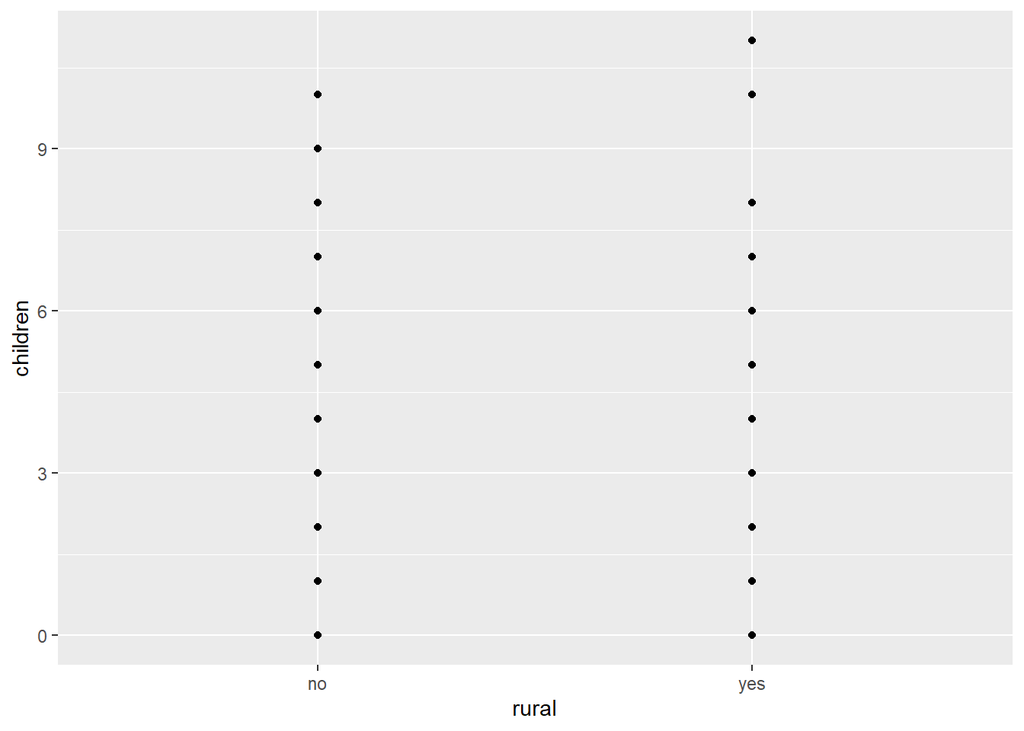

```r
library(ggplot2)

ggplot(data = df,
       mapping = aes(x = rural,
                     y = children)) +

  geom_point() +

  geom_smooth()
```

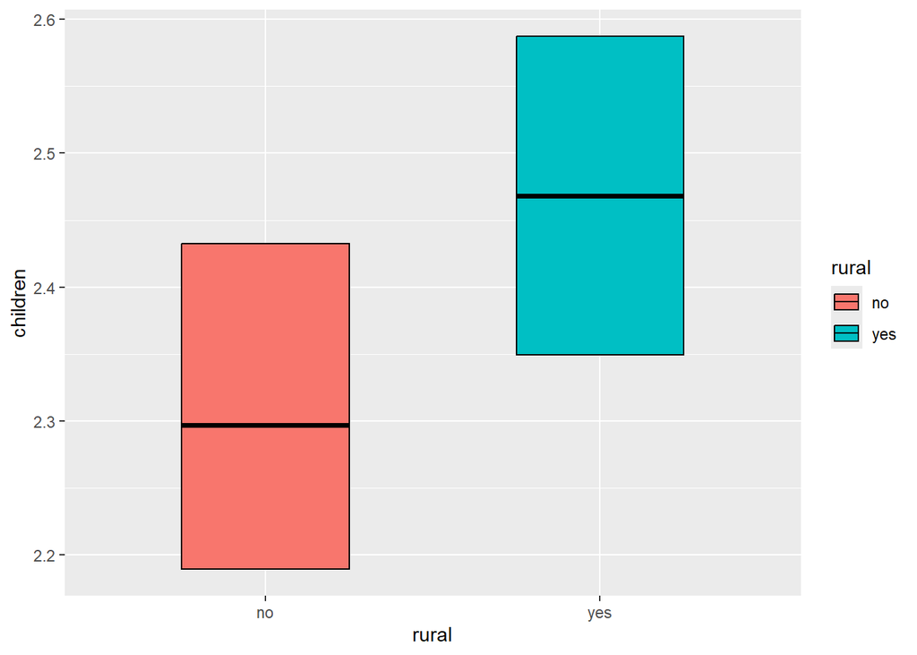

```r
library(ggplot2)
library(Hmisc)
ggplot(data = df,
       mapping = aes(x = rural,
                     y = children)) +

  # geom_boxplot() +

  stat_summary(fun.data = mean_cl_boot,
               geom ='crossbar',
               width = 0.5,
               aes(fill = rural),
               position = position_dodge2(padding = 0.3))
```

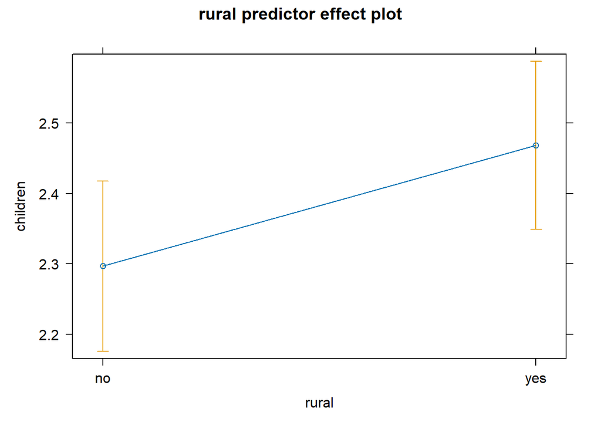

```r
effects:::plot.efflist(predictorEffects(m2, ~ rural))
```

### 5.2.2 Predict

Nếu một người phụ nữ ở nông thôn thì số con trung bình sinh ra là bao nhiêu.

```r
data_pred <- data.frame(rural = "yes")

data_pred$rural <- factor(data_pred$rural,
                          levels = c("no", "yes"))

pred2 <- predict(m2,
                 newdata = data_pred,
                 interval = "confidence")

pred2
```

```
       fit      lwr      upr
1 2.468254 2.349082 2.587426
```

## 5.3 Y numeric | X category (>2 mức)

```r
levels(df$religion)
```

```
[1] "Catholic"   "Muslim"     "Protestant" "Other"
```

$$\text{children (religion = Catholic)} = 2.17692 + 0.25734 \times \text{(religion = Muslim | 0)} -0.06125 \times \text{(religion = Protestant | 0)} + 2.14308 \times \text{(religion = Other | 0)} = 2.1769$$

$$\text{children (religion = Muslim)} = 2.17692 + 0.25734 \times \text{(religion = Muslim | 1)} -0.06125 \times \text{(religion = Protestant | 0)} + 2.14308 \times \text{(religion = Other | 0)} = 2.17692 + 0.25734 = 2.43422$$

$$\text{children (religion = Protestant)} = 2.17692 + 0.25734 \times \text{(religion = Muslim | 0)} -0.06125 \times \text{(religion = Protestant | Protestant)} + 2.14308 \times \text{(religion = Other | 0)} = 2.17692 - 0.06125 = 2.11567$$

$$\text{children (religion = Other)} = 2.17692 + 0.25734 \times \text{(religion = Muslim | 0)} -0.06125 \times \text{(religion = Protestant | Protestant)} + 2.14308 \times \text{(religion = Other | 1)} = 2.17692 + 2.14308 = 4.32$$

```r
aggregate(children ~ religion,
          data = df,
          FUN = mean)
```

```
    religion children
1   Catholic 2.176923
2     Muslim 2.434263
3 Protestant 2.115672
4      Other 4.320000
```

```r
m3 <- lm(children ~ religion,
          data = df)

summary(m3)
```

```
Call:
lm(formula = children ~ religion, data = df)

Residuals:
    Min      1Q  Median      3Q     Max
-4.3200 -1.1157 -0.1157  0.6800  8.8843

Coefficients:
                   Estimate Std. Error t value Pr(>|t|)
(Intercept)         2.17692    0.12625  17.243   <2e-16 ***
religionMuslim      0.25734    0.14166   1.817   0.0695 .
religionProtestant -0.06125    0.14073  -0.435   0.6635
religionOther       2.14308    0.20873  10.267   <2e-16 ***
---
Signif. codes:  0 '***' 0.001 '**' 0.01 '*' 0.05 '.' 0.1 ' ' 1

Residual standard error: 1.44 on 1239 degrees of freedom
Multiple R-squared:  0.1128,    Adjusted R-squared:  0.1107
F-statistic: 52.53 on 3 and 1239 DF,  p-value: < 2.2e-16
```

### 5.3.1 Effect plot

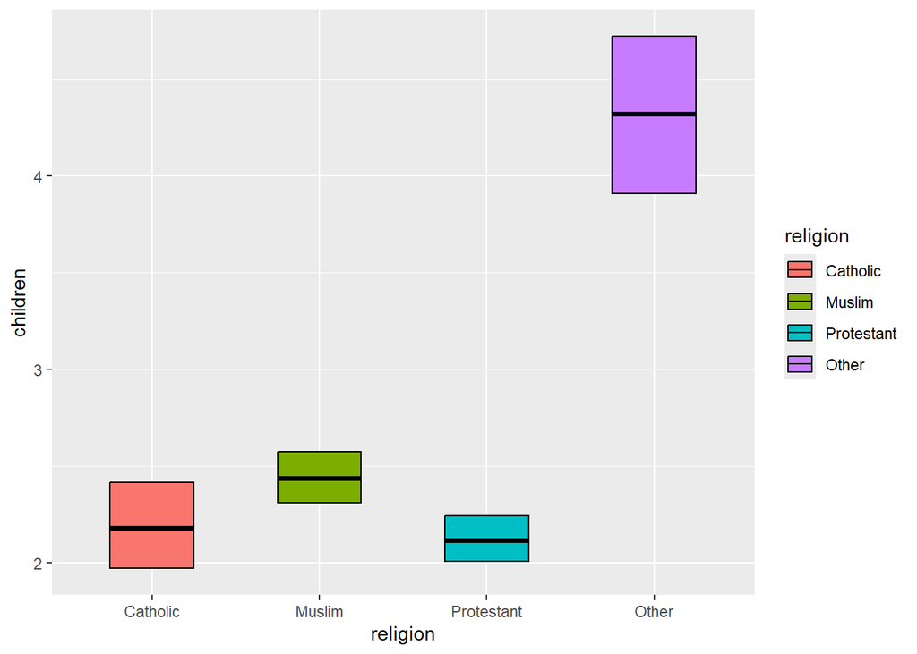

```r
library(ggplot2)
library(Hmisc)
ggplot(data = df,
       mapping = aes(x = religion,
                     y = children)) +

  # geom_boxplot() +

  stat_summary(fun.data = mean_cl_boot,
               geom ='crossbar',
               width = 0.5,
               aes(fill = religion),
               position = position_dodge2(padding = 0.3))
```

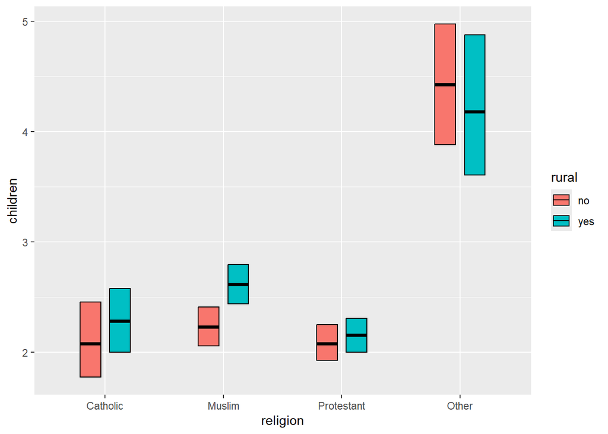

```r
library(ggplot2)
library(Hmisc)
ggplot(data = df,
       mapping = aes(x = religion,
                     y = children)) +

  # geom_boxplot() +

  stat_summary(fun.data = mean_cl_boot,
               geom ='crossbar',
               width = 0.5,
               aes(fill = rural),
               position = position_dodge2(padding = 0.3))
```

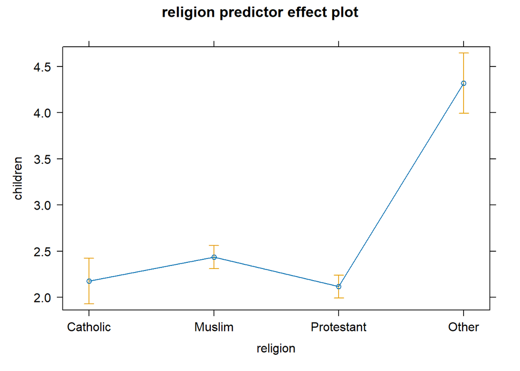

```r
effects:::plot.efflist(predictorEffects(m3, ~religion))
```

# 6 Multiple regression

```r
dr <- df_ori
```

## 6.1 Y numeric | X1 numeric + X2 numeric | Không tương tác

$$Y = \beta_0 + \beta_1 \times X_1 + \beta_2 \times X_2 + \epsilon$$

$$\text{children} = 6.14825 -0.21015 \times \text{years\_school} -0.08018 \times \text{age\_marriage}$$

Khi `years_school` tăng lên 1 đơn vị thì `children` giảm đi -0.21 đơn vị, trong điều kiện các biến khác giữ ở giá trị trung bình.

As `years_school` increases by one unit, `children` decreases by 0.21 units on average, *ceteris paribus* (nghĩa là: với điều kiện các yếu tố khác không đổi)

```r
fit1 <- lm(children ~ years_school + age_marriage,
           data = dr)

summary(fit1)
```

```
Call:
lm(formula = children ~ years_school + age_marriage, data = dr)

Residuals:
    Min      1Q  Median      3Q     Max
-3.1040 -0.8727 -0.2525  0.6674  8.7475

Coefficients:
             Estimate Std. Error t value Pr(>|t|)
(Intercept)   6.14825    0.47516  12.939  < 2e-16 ***
years_school -0.21015    0.04542  -4.627 4.09e-06 ***
age_marriage -0.08018    0.01408  -5.694 1.54e-08 ***
---
Signif. codes:  0 '***' 0.001 '**' 0.01 '*' 0.05 '.' 0.1 ' ' 1

Residual standard error: 1.488 on 1240 degrees of freedom
Multiple R-squared:  0.05103,   Adjusted R-squared:  0.0495
F-statistic: 33.34 on 2 and 1240 DF,  p-value: 7.858e-15
```

### 6.1.1 Model validate

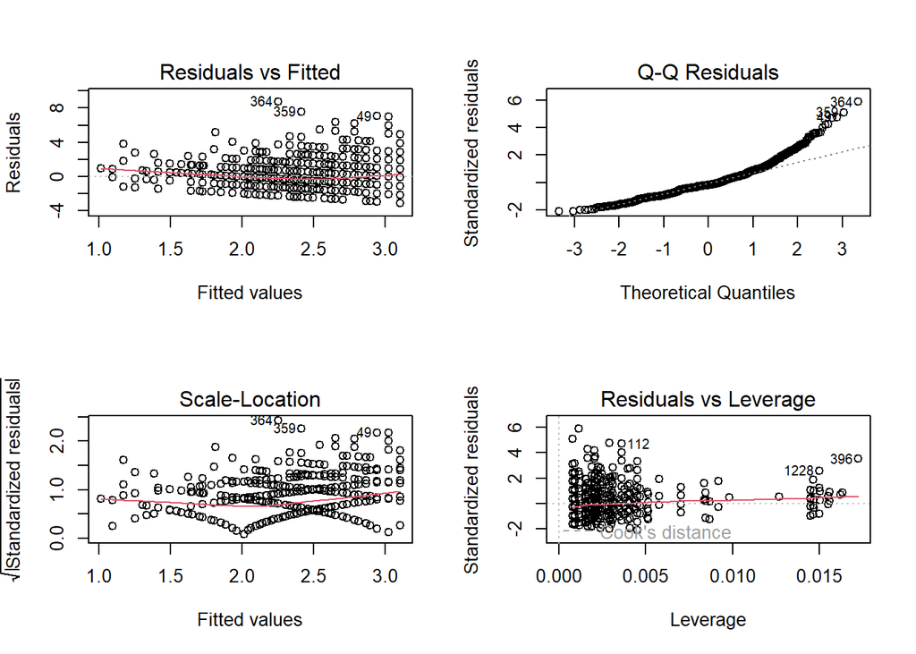

```r
par(mfrow = c(2,2))

plot(fit1)
```

```r
performance:::performance(fit1)
```

```
# Indices of model performance

AIC    |   AICc |    BIC |    R2 | R2 (adj.) |  RMSE | Sigma
------------------------------------------------------------
4520.8 | 4520.9 | 4541.3 | 0.051 |     0.050 | 1.486 | 1.488
```

#### 6.1.1.1 Residuals | Normality

Kiểm tra phân bố chuẩn của phần dư

```r
performance:::check_normality(fit1)
```

#### 6.1.1.2 Residuals | Heteroscedasticity

Kiểm tra phương sai thay đổi trong mô hình hồi quy.

```r
performance:::check_heteroscedasticity(fit1)
```

```r
library(lmtest)

# Goldfeld-Quandt test against heteroskedasticity.
# H0: Homogeneity phương sai của sai số không đổi giữa hai nhóm quan sát. Heteroscedasticity is not present.

# H1: Heteroskedasticity phương sai của sai số thay đổi giữa hai nhóm quan sát. Heteroscedasticity is present.

lmtest:::gqtest(fit1)
```

```
    Goldfeld-Quandt test

data:  fit1
GQ = 0.81275, df1 = 619, df2 = 618, p-value = 0.995
alternative hypothesis: variance increases from segment 1 to 2
```

```r
# Breusch–Pagan test
lmtest:::bptest(fit1)
```

```
    studentized Breusch-Pagan test

data:  fit1
BP = 23.872, df = 2, p-value = 6.549e-06
```

```r
# White test
library(skedastic)
skedastic:::white(fit1)
```

```
# A tibble: 1 × 5
  statistic       p.value parameter method       alternative
      <dbl>         <dbl>     <dbl> <chr>        <chr>
1      45.0 0.00000000388         4 White's Test greater
```

#### 6.1.1.3 Residuals | Autocorrelation

```r
performance:::check_autocorrelation(fit1)
library(car)
car:::dwt(fit1)
```

```
 lag Autocorrelation D-W Statistic p-value
   1       0.1706235      1.657427       0
 Alternative hypothesis: rho != 0
```

#### 6.1.1.4 Residuals | Collinearity

```r
library(car)

car:::vif(fit1)
```

```
years_school age_marriage
    1.039724     1.039724
```

```r
performance:::check_collinearity(fit1)
```

```
# Check for Multicollinearity

Low Correlation

         Term  VIF   VIF 95% CI adj. VIF Tolerance Tolerance 95% CI
 years_school 1.04 [1.01, 1.18]     1.02      0.96     [0.85, 0.99]
 age_marriage 1.04 [1.01, 1.18]     1.02      0.96     [0.85, 0.99]
```

### 6.1.2 Standard errors

```r
# Conventional standard errors

lmtest:::coeftest(fit1)
```

```
t test of coefficients:

              Estimate Std. Error t value  Pr(>|t|)
(Intercept)   6.148247   0.475162 12.9393 < 2.2e-16 ***
years_school -0.210151   0.045416 -4.6273 4.094e-06 ***
age_marriage -0.080177   0.014080 -5.6944 1.545e-08 ***
---
Signif. codes:  0 '***' 0.001 '**' 0.01 '*' 0.05 '.' 0.1 ' ' 1
```

```r
confint(fit1)
```

```
                  2.5 %      97.5 %
(Intercept)   5.2160364  7.08045768
years_school -0.2992508 -0.12105046
age_marriage -0.1078010 -0.05255393
```

```r
# Robust standard errors

library(sandwich)
lmtest:::coeftest(fit1, vcov = vcovHC(fit1, type = "HC3"))
```

```
t test of coefficients:

              Estimate Std. Error t value  Pr(>|t|)
(Intercept)   6.148247   0.547893 11.2216 < 2.2e-16 ***
years_school -0.210151   0.046901 -4.4807 8.127e-06 ***
age_marriage -0.080177   0.014839 -5.4033 7.837e-08 ***
---
Signif. codes:  0 '***' 0.001 '**' 0.01 '*' 0.05 '.' 0.1 ' ' 1
```

### 6.1.3 Effect plot

**Effect plot này có thể sử dụng khoảng tin cậy từ conventional standard error, ta có thể tính thủ công và vẽ lại effect plot sử dụng robust standard error nếu muốn chính xác hơn.**

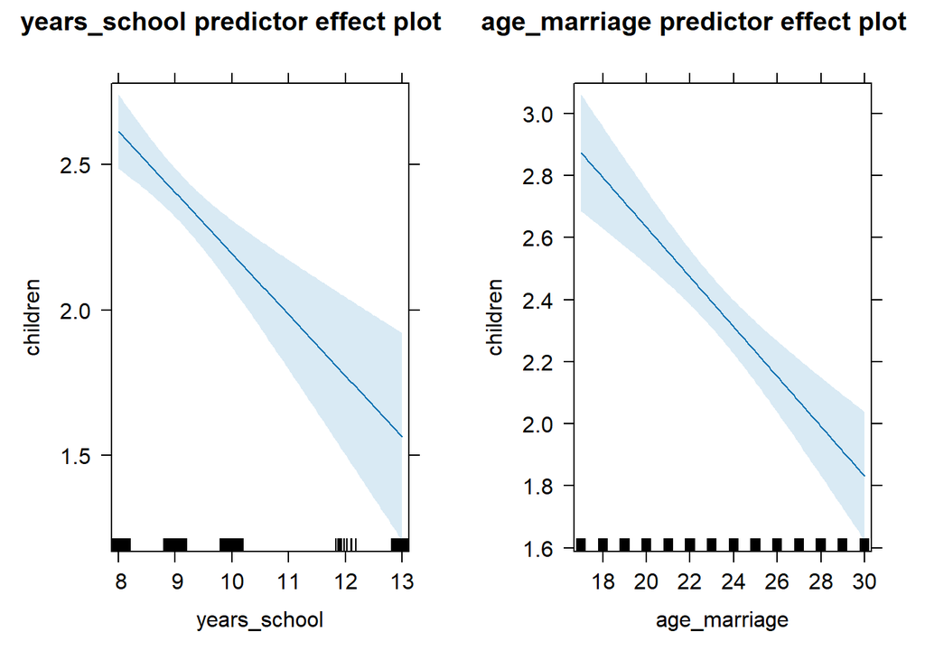

```r
effects:::plot.efflist(predictorEffects(fit1, ~ years_school + age_marriage))
```

## 6.2 Y numeric | X1 numeric + X2 numeric | Có tương tác

$$Y = \beta_0 + \beta_1 \times X_1 + \beta_2 \times X_2 + \beta_3 \times X_1 \times X_2 + \epsilon$$

$$\text{children} = 17.82888 -1.51479 \times \text{years\_school} -0.56368 \times \text{age\_marriage} + 0.05390 \times \text{years\_school} \times \text{age\_marriage}$$

```r
fit2 <- lm(children ~ years_school * age_marriage,
           data = dr)

summary(fit2)
```

```
Call:
lm(formula = children ~ years_school * age_marriage, data = dr)

Residuals:
    Min      1Q  Median      3Q     Max
-3.4580 -0.9644 -0.2306  0.7345  8.7694

Coefficients:
                          Estimate Std. Error t value Pr(>|t|)
(Intercept)               17.82888    3.18209   5.603 2.60e-08 ***
years_school              -1.51479    0.35436  -4.275 2.06e-05 ***
age_marriage              -0.56368    0.13101  -4.303 1.82e-05 ***
years_school:age_marriage  0.05390    0.01452   3.712 0.000215 ***
---
Signif. codes:  0 '***' 0.001 '**' 0.01 '*' 0.05 '.' 0.1 ' ' 1

Residual standard error: 1.481 on 1239 degrees of freedom
Multiple R-squared:  0.06147,   Adjusted R-squared:  0.0592
F-statistic: 27.05 on 3 and 1239 DF,  p-value: < 2.2e-16
```

```r
fit2a <- lm(children ~ years_school + age_marriage + years_school:age_marriage,
           data = dr)

summary(fit2a)
```

```
Call:
lm(formula = children ~ years_school + age_marriage + years_school:age_marriage,
    data = dr)

Residuals:
    Min      1Q  Median      3Q     Max
-3.4580 -0.9644 -0.2306  0.7345  8.7694

Coefficients:
                          Estimate Std. Error t value Pr(>|t|)
(Intercept)               17.82888    3.18209   5.603 2.60e-08 ***
years_school              -1.51479    0.35436  -4.275 2.06e-05 ***
age_marriage              -0.56368    0.13101  -4.303 1.82e-05 ***
years_school:age_marriage  0.05390    0.01452   3.712 0.000215 ***
---
Signif. codes:  0 '***' 0.001 '**' 0.01 '*' 0.05 '.' 0.1 ' ' 1

Residual standard error: 1.481 on 1239 degrees of freedom
Multiple R-squared:  0.06147,   Adjusted R-squared:  0.0592
F-statistic: 27.05 on 3 and 1239 DF,  p-value: < 2.2e-16
```

### 6.2.1 Interaction

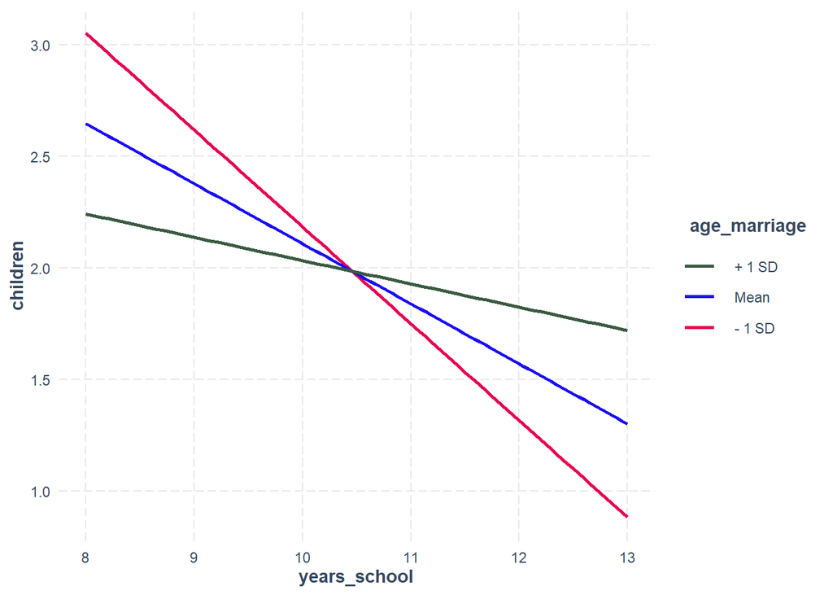

```r
library(interactions)

interactions:::interact_plot(fit2,
                             pred = years_school,
                             modx = age_marriage,
                             vary.lty = F,
                             colors = c("red", "blue", "darkgreen"))
```

Nhận xét xu hướng:

- Đường Mean (xanh dương): Khi số năm đi học (`years_school`) tăng, số con trung bình có xu hướng giảm. Điều này cho thấy mối quan hệ tỷ lệ nghịch giữa trình độ học vấn và số con.
- Đường +1 SD của `age_marriage` (xanh lá cây): Đại diện cho nhóm phụ nữ có tuổi kết hôn `age_marriage` (kết hôn muộn) cao hơn mức trung bình 1 độ lệch chuẩn. Đường này có độ dốc âm tương đối nhỏ, cho thấy số năm đi học tăng lên thì số con trung bình giảm nhưng mức độ giảm không mạnh trong nhóm phụ nữ kết hôn muộn.
- Đường -1 SD của `age_marriage` (màu đỏ): Đại diện cho nhóm phụ nữ có tuổi kết hôn thấp `age_marriage` (kết hôn sớm) hơn mức trung bình 1 độ lệch chuẩn. Đường này có độ dốc âm rất lớn, cho thấy số năm đi học tăng lên thì số con trung bình giảm mạnh hơn đáng kể trong nhóm phụ nữ kết hôn sớm.

Biểu đồ cho thấy độ dốc của ba đường hồi quy khác nhau, chứng tỏ tác động của số năm đi học (`years_school`) lên số con trung bình (`children`) thay đổi tùy theo tuổi kết hôn (`age_marriage`).

Cụ thể, ở nhóm phụ nữ kết hôn muộn (+1 SD), số năm đi học tăng lên chỉ làm giảm nhẹ số con trung bình. Ngược lại, ở nhóm phụ nữ kết hôn sớm (-1 SD), số năm đi học tăng lên có liên hệ với sự sụt giảm mạnh hơn trong số con trung bình.

Điều này gợi ý rằng tuổi kết hôn có thể đóng vai trò điều tiết (moderating effect) trong mối quan hệ giữa trình độ học vấn và số con.

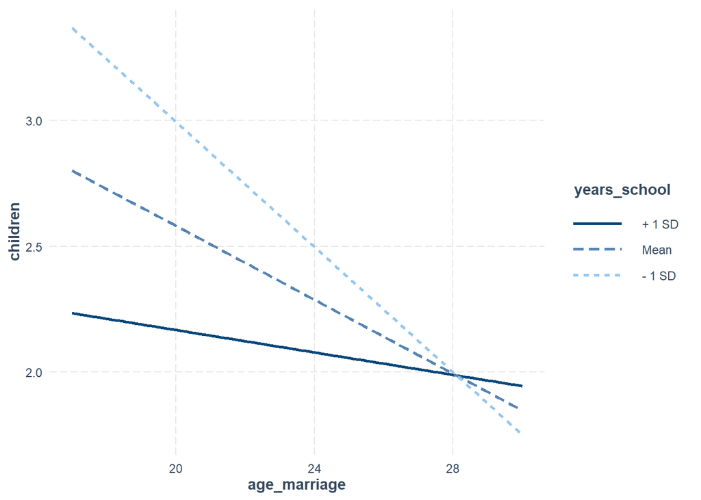

```r
interactions:::interact_plot(fit2,
                             pred = age_marriage,
                             modx = years_school)
```

### 6.2.2 Effect plot

```r
png(filename = "int1.png",
    width = 12,
    height = 6,
    units = "in",
    res = 300)

effects:::plot.efflist(predictorEffects(fit2, ~ years_school + age_marriage))

dev.off()
```

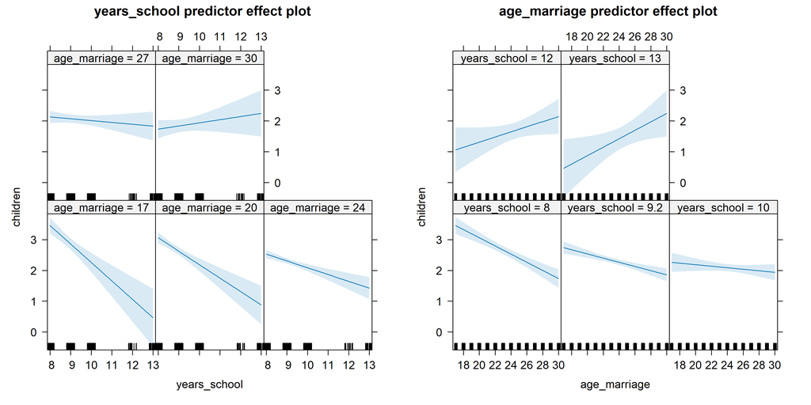

## 6.3 Y numeric | X1 numeric + X2 category | Không tương tác

$$Y = \beta_0 + \beta_1 \times X_1 + \beta_2 \times X_2 + \epsilon$$

$$\text{children} = 4.87182 -0.07645 \times \text{age\_marriage} -0.89834 \times \text{(german = no | 0)} = 4.87182 -0.07645 \times \text{age\_marriage}$$

$$\text{children} = 4.87182 -0.07645 \times \text{age\_marriage} -0.89834 \times \text{(german = yes | 1)} = 3.97348 -0.07645 \times \text{age\_marriage}$$

```r
fit3 <- lm(children ~ age_marriage + german,
           data = dr)

summary(fit3)
```

```
Call:
lm(formula = children ~ age_marriage + german, data = dr)

Residuals:
    Min      1Q  Median      3Q     Max
-3.5721 -0.9857 -0.2150  0.7085  8.9379

Coefficients:
             Estimate Std. Error t value Pr(>|t|)
(Intercept)   4.87182    0.31799  15.321  < 2e-16 ***
age_marriage -0.07645    0.01367  -5.593 2.75e-08 ***
germanyes    -0.89834    0.10504  -8.552  < 2e-16 ***
---
Signif. codes:  0 '***' 0.001 '**' 0.01 '*' 0.05 '.' 0.1 ' ' 1

Residual standard error: 1.459 on 1240 degrees of freedom
Multiple R-squared:  0.08842,   Adjusted R-squared:  0.08695
F-statistic: 60.13 on 2 and 1240 DF,  p-value: < 2.2e-16
```

### 6.3.1 Đồ thị

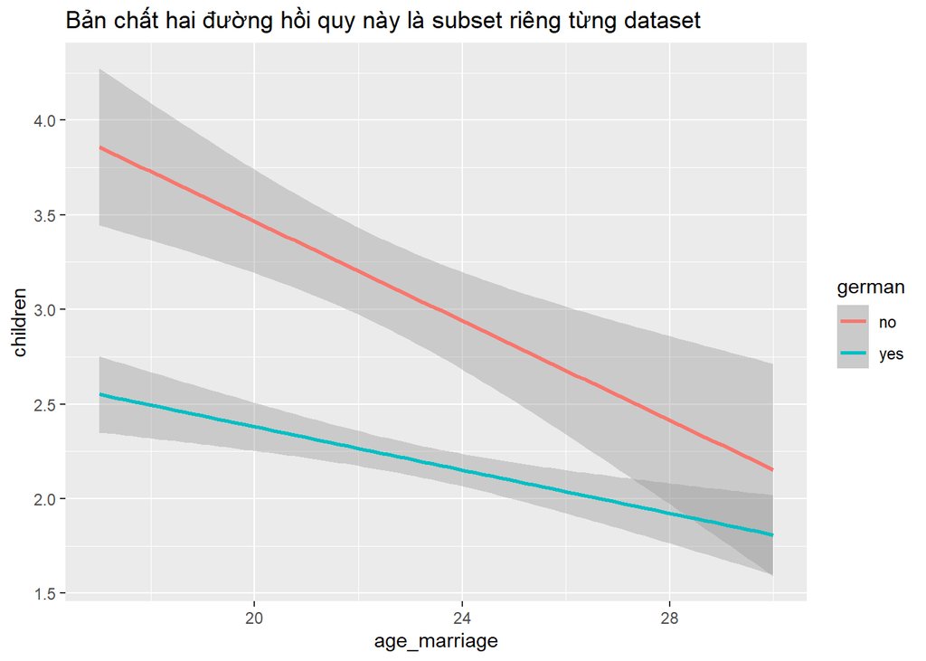

```r
library(ggplot2)

ggplot(data = dr,
       mapping = aes(x = age_marriage,
                     y = children,
                     color = german)) +

  # geom_point() +

  geom_smooth(method = "lm") +

  labs(title = "Bản chất hai đường hồi quy này là subset riêng từng dataset")
```

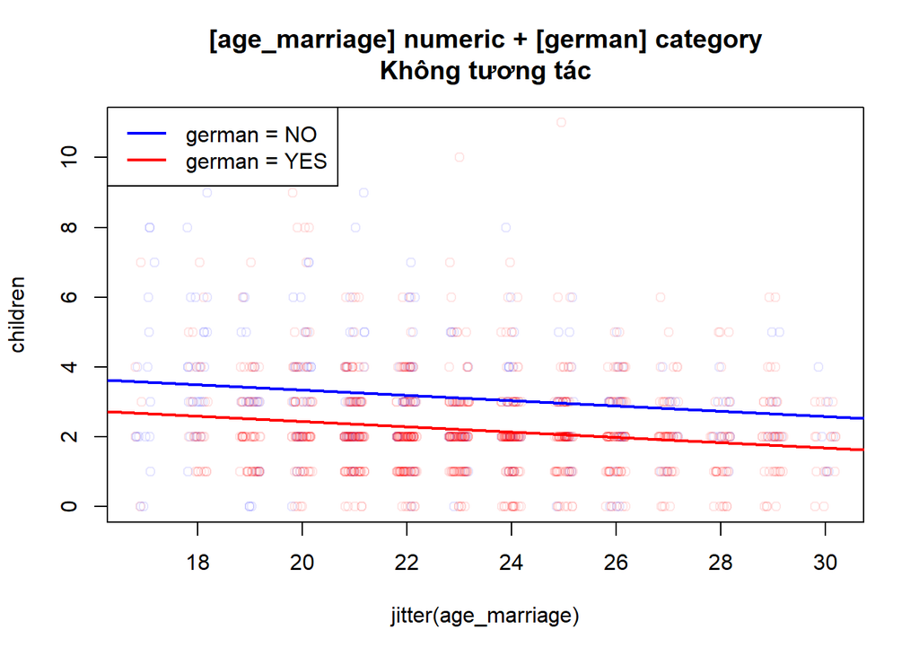

```r
plot(children ~ jitter(age_marriage),
     data = dr,
     col = c(adjustcolor("blue", alpha.f = 0.1),
             adjustcolor("red", alpha.f = 0.1))[factor(dr$german)],
     main = "[age_marriage] numeric + [german] category\nKhông tương tác"
     )

abline(a = coef(fit3)[1],
       b = coef(fit3)[2],
       col = "blue",
       lwd = 2)

abline(a = coef(fit3)[1] + coef(fit3)[3],
       b = coef(fit3)[2],
       col = "red",
       lwd = 2)

legend(x = "topleft",
       y = NULL,
       legend = c("german = NO", "german = YES"),
       col = c("blue", "red"),
       lwd = 2,
       lty = 1
       )
```

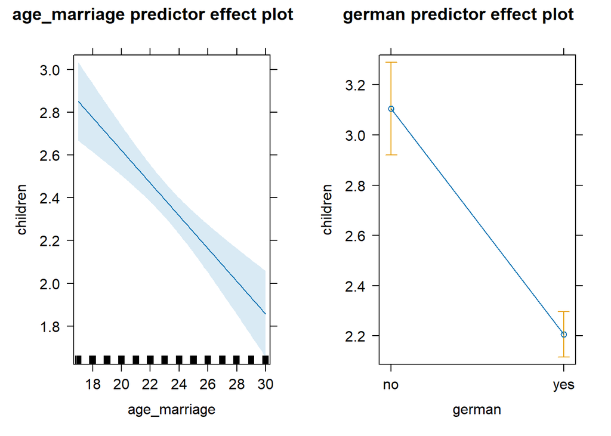

```r
library(effects)

effects:::plot.efflist(predictorEffects(fit3, ~ age_marriage + german))
```

## 6.4 Y numeric | X1 numeric + X2 category | Có tương tác

$$\text{children} = 6.09240 -0.13133 \times \text{age\_marriage} -2.56918 \times \text{(german = no | 0)} + 0.07419 \times \text{age\_marriage} \times \text{(german = no | 0)} = 6.09240 -0.13133 \times \text{age\_marriage}$$

```r
fit4 <- lm(children ~ age_marriage * german,
           data = dr)

summary(fit4)
```

```
Call:
lm(formula = children ~ age_marriage * german, data = dr)

Residuals:
    Min      1Q  Median      3Q     Max
-3.8597 -1.0374 -0.2088  0.7340  8.9055

Coefficients:
                       Estimate Std. Error t value Pr(>|t|)
(Intercept)             6.09240    0.60209  10.119  < 2e-16 ***
age_marriage           -0.13133    0.02675  -4.910 1.03e-06 ***
germanyes              -2.56918    0.70818  -3.628 0.000297 ***
age_marriage:germanyes  0.07419    0.03110   2.386 0.017199 *
---
Signif. codes:  0 '***' 0.001 '**' 0.01 '*' 0.05 '.' 0.1 ' ' 1

Residual standard error: 1.456 on 1239 degrees of freedom
Multiple R-squared:  0.09258,   Adjusted R-squared:  0.09039
F-statistic: 42.14 on 3 and 1239 DF,  p-value: < 2.2e-16
```

### 6.4.1 Đồ thị

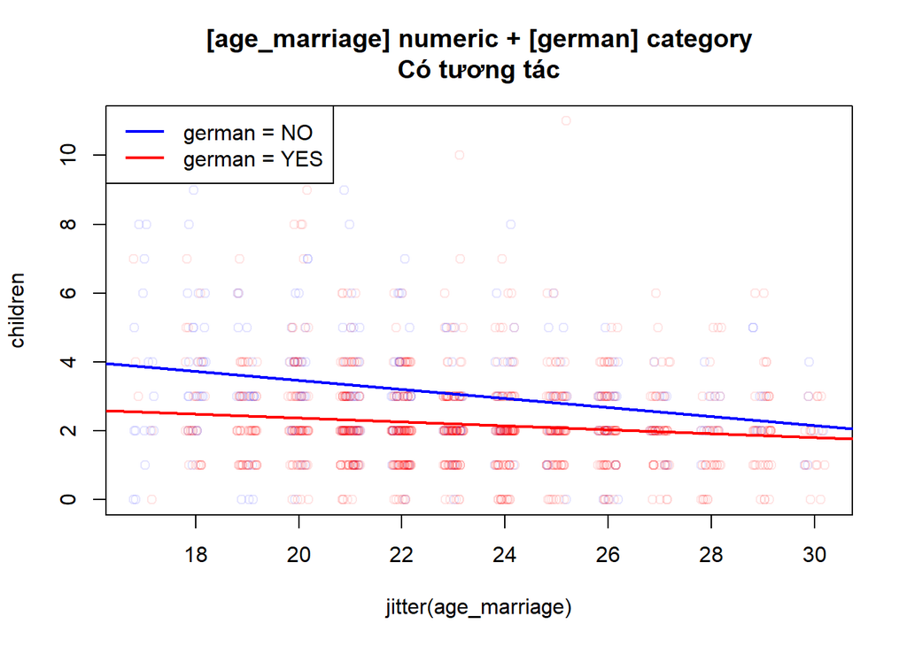

```r
plot(children ~ jitter(age_marriage),
     data = dr,
     col = c(adjustcolor("blue", alpha.f = 0.1),
             adjustcolor("red", alpha.f = 0.1))[factor(dr$german)],
     main = "[age_marriage] numeric + [german] category\nCó tương tác"
     )

abline(a = coef(fit4)[1],
       b = coef(fit4)[2],
       col = "blue",
       lwd = 2)

abline(a = coef(fit4)[1] + coef(fit4)[3],
       b = coef(fit4)[2] + coef(fit4)[4],
       col = "red",
       lwd = 2)

legend(x = "topleft",
       y = NULL,
       legend = c("german = NO", "german = YES"),
       col = c("blue", "red"),
       lwd = 2,
       lty = 1
       )
```

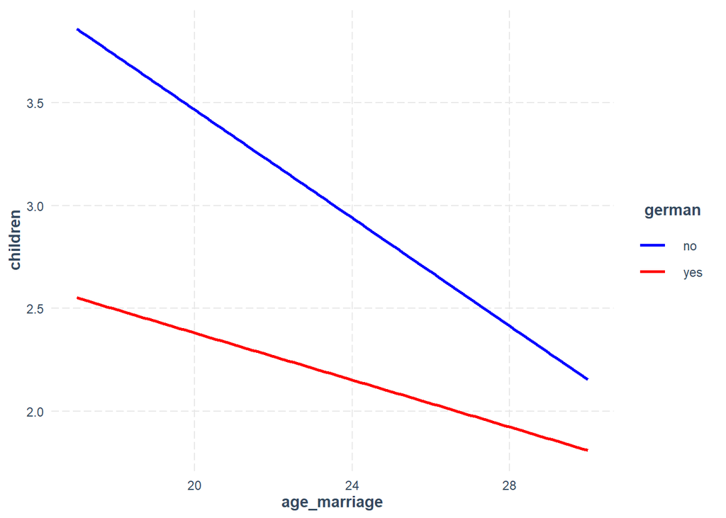

```r
library(interactions)

interactions:::interact_plot(fit4,
                             pred = age_marriage,
                             modx = german,
                             vary.lty = F,
                             colors = c("blue", "red"))
```

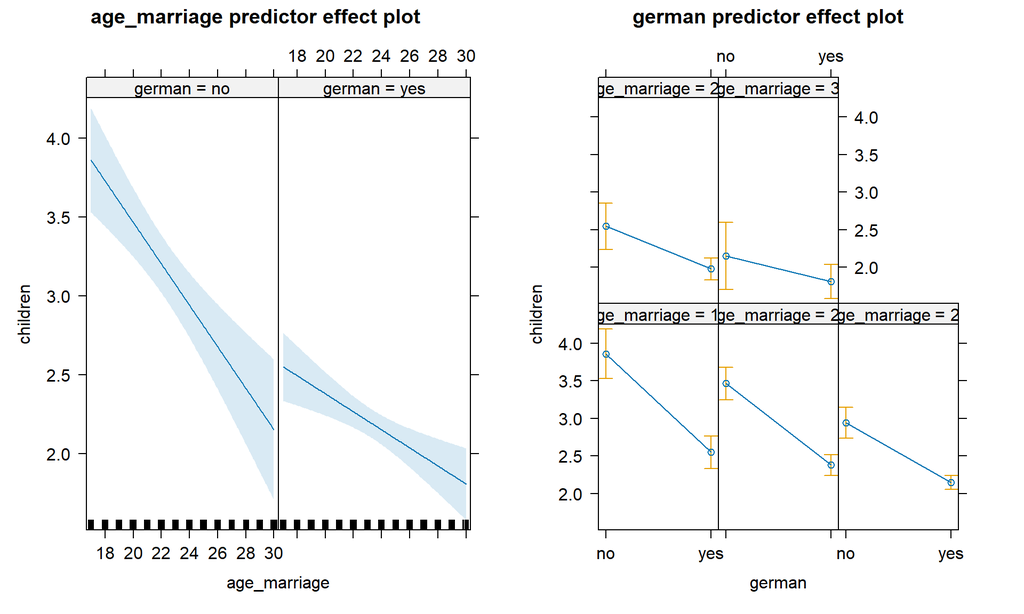

```r
library(effects)

effects:::plot.efflist(predictorEffects(fit4, ~ age_marriage + german))
```

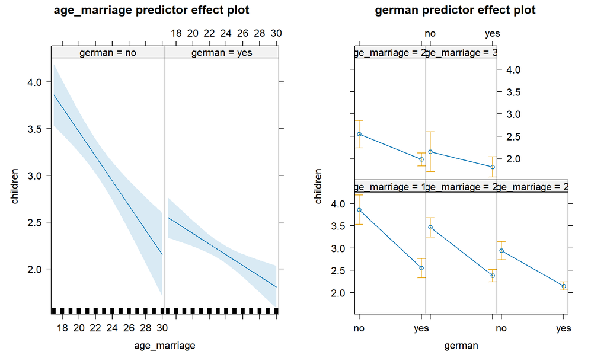

```r
effects:::plot.efflist(predictorEffects(fit4, ~ age_marriage + german))
```

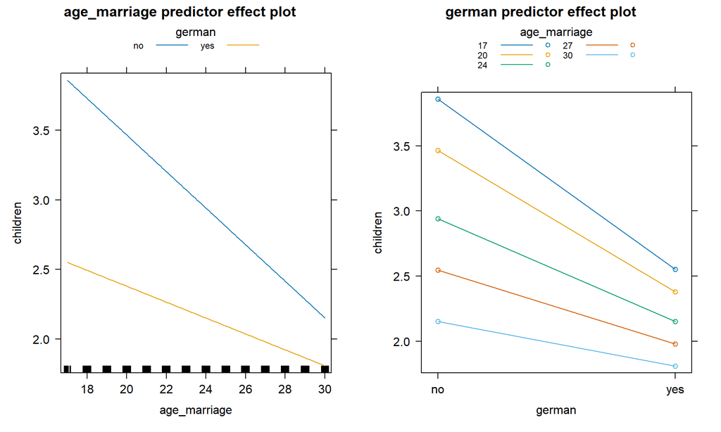

```r
effects:::plot.efflist(effects:::predictorEffects(fit4, ~ age_marriage + german),
                       lines = list(multiline = TRUE))
```

### 6.4.2 ANCOVA | Đánh giá tác động của `german` (yes|no) khi được điều chỉnh bởi `age_marriage`

```r
fit5 <- aov(children ~ age_marriage * german,
           data = dr)

summary(fit5)
```

```
                      Df Sum Sq Mean Sq F value   Pr(>F)
age_marriage           1  100.3  100.27  47.309 9.59e-12 ***
german                 1  155.6  155.60  73.415  < 2e-16 ***
age_marriage:german    1   12.1   12.06   5.691   0.0172 *
Residuals           1239 2626.0    2.12
---
Signif. codes:  0 '***' 0.001 '**' 0.01 '*' 0.05 '.' 0.1 ' ' 1
```

Ta quan tâm hiệu ứng interaction:

Nếu p ≥ 0,05: Chưa tìm thấy bằng chứng rõ ràng rằng độ dốc khác nhau giữa các nhóm. Có thể tiếp tục xem xét ANCOVA không tương tác nếu các giả định khác phù hợp.

Nếu p < 0,05: Có bằng chứng về tương tác. Khi đó, nên giữ mô hình tương tác và đánh giá sự khác biệt giữa các nhóm tại những giá trị `age_marriage` ban đầu cụ thể.

Những giả định ANCOVA cần kiểm tra:

1. Các quan sát độc lập.
2. Mối liên hệ gần tuyến tính giữa covariate (biến X numeric) và biến phụ thuộc (biến Y numeric).
3. Độ dốc hồi quy giữa các nhóm tương đối đồng nhất đối với mô hình không tương tác
4. Phần dư có phương sai tương đối đồng nhất và phân phối đủ phù hợp với suy luận của mô hình.
5. Không có các điểm ngoại lai ảnh hưởng quá mạnh đến kết quả.

```r
library(emmeans)
emm <- emmeans(fit5, ~ german)
summary(emm)
```

```
 german emmean     SE   df lower.CL upper.CL
 no       3.06 0.0959 1239     2.87     3.25
 yes      2.20 0.0462 1239     2.11     2.29

Confidence level used: 0.95
```

```r
confint(emm)
```

```
 german emmean     SE   df lower.CL upper.CL
 no       3.06 0.0959 1239     2.87     3.25
 yes      2.20 0.0462 1239     2.11     2.29

Confidence level used: 0.95
```

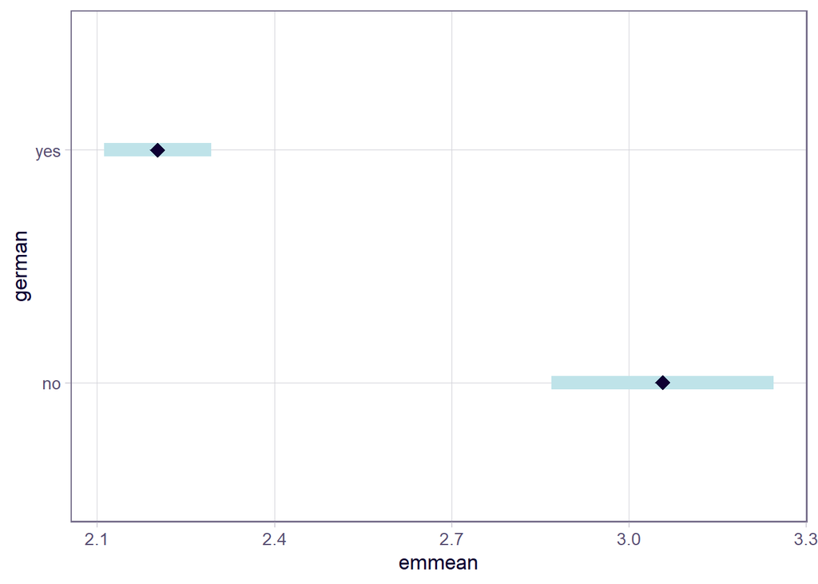

```r
# plot(emm)
emmeans:::plot.emmGrid(emm)
```

```r
# Partial eta squared cho hiệu ứng nhóm
tab <- car:::Anova(fit5, type = 2)
tab
```

```
Anova Table (Type II tests)

Response: children
                     Sum Sq   Df F value    Pr(>F)
age_marriage          66.55    1 31.3978 2.588e-08 ***
german               155.60    1 73.4149 < 2.2e-16 ***
age_marriage:german   12.06    1  5.6913    0.0172 *
Residuals           2626.02 1239
---
Signif. codes:  0 '***' 0.001 '**' 0.01 '*' 0.05 '.' 0.1 ' ' 1
```

```r
eta_p2 <- tab["german", "Sum Sq"] /
  (tab["german", "Sum Sq"] +
   tab["Residuals", "Sum Sq"])

eta_p2
```

```
[1] 0.05593878
```

```r
emm_int <- emmeans(
  fit5,
  ~ german | age_marriage,
  at = list(age_marriage = c(20, 30, 40))
)

pairs(emm_int, adjust = "tukey")
```

```
age_marriage = 20:
 contrast estimate    SE   df t.ratio p.value
 no - yes    1.085 0.131 1239   8.290 <0.0001

age_marriage = 30:
 contrast estimate    SE   df t.ratio p.value
 no - yes    0.344 0.255 1239   1.347  0.1782

age_marriage = 40:
 contrast estimate    SE   df t.ratio p.value
 no - yes   -0.398 0.554 1239  -0.720  0.4720
```

**Kết quả cho biết sự khác biệt giữa số con trung bình của phụ nữ là [german] hoặc [không phải là german] tại các độ tuổi kết hôn khác nhau.**

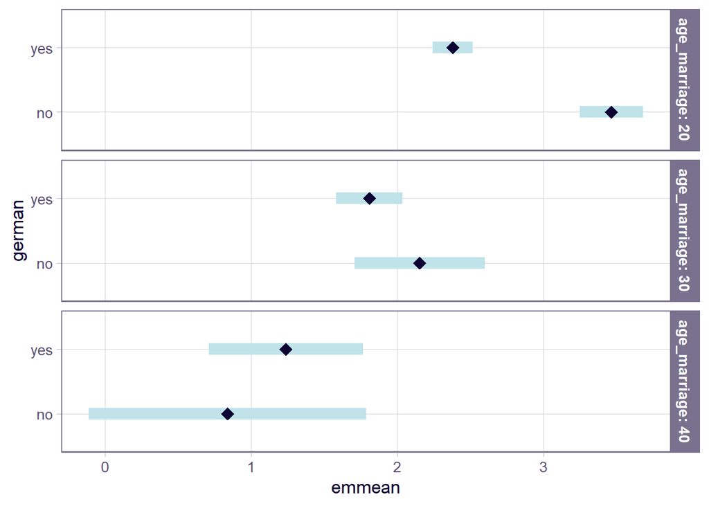

```r
# plot(emm_int)
emmeans:::plot.emmGrid(emm_int)
```

Cách trình bày kết quả trong bài báo khoa học:

Phân tích hiệp phương sai (ANCOVA) được sử dụng nhằm so sánh hai nhóm phụ nữ là [german] hoặc [không phải là german], với `age_marriage` được đưa vào mô hình như một biến covariate (biến phụ, hiệu chỉnh). Sau khi điều chỉnh, ghi nhận sự khác biệt có ý nghĩa thống kê giữa các nhóm, F = 73.4149; p = < 0.001 (dùng kết quả của lệnh `car:::Anova()` ở biến `german`); partial η² = 0.055. Phân tích hậu kiểm sử dụng phương pháp Tukey được thực hiện để xác định sự khác biệt giữa các cặp nhóm.

## 6.5 Y numeric | X1 category + X2 category | Có tương tác

```r
fit6 <- lm(children ~ rural * german,
           data = dr)

summary(fit6)
```

```
Call:
lm(formula = children ~ rural * german, data = dr)

Residuals:
    Min      1Q  Median      3Q     Max
-3.2787 -1.0530 -0.0650  0.6765  8.6765

Coefficients:
                   Estimate Std. Error t value Pr(>|t|)
(Intercept)          3.2787     0.1332  24.607  < 2e-16 ***
ruralyes            -0.2136     0.1880  -1.136   0.2561
germanyes           -1.2257     0.1489  -8.233 4.58e-16 ***
ruralyes:germanyes   0.4842     0.2099   2.307   0.0212 *
---
Signif. codes:  0 '***' 0.001 '**' 0.01 '*' 0.05 '.' 0.1 ' ' 1

Residual standard error: 1.472 on 1239 degrees of freedom
Multiple R-squared:  0.07269,   Adjusted R-squared:  0.07045
F-statistic: 32.38 on 3 and 1239 DF,  p-value: < 2.2e-16
```

### 6.5.1 Đồ thị

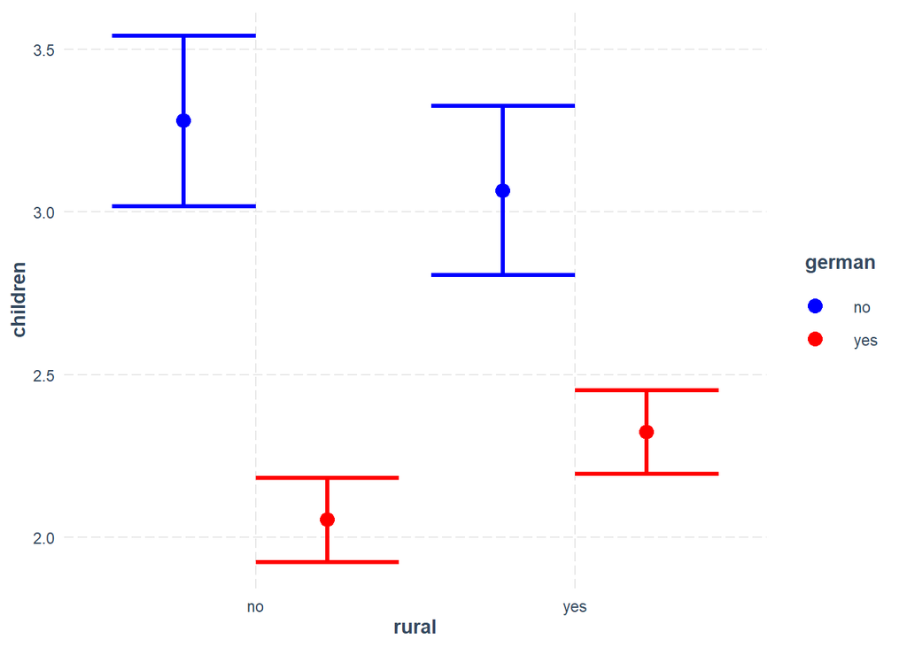

```r
library(interactions)

interactions:::cat_plot(fit6,
                        pred = rural,
                        modx = german,
                        vary.lty = F,
                        colors = c("blue", "red"))
```

### 6.5.2 ANOVA 2 YẾU TỐ

```r
fit7 <- aov(children ~ rural * german,
           data = dr)

summary(fit7)
```

```
               Df Sum Sq Mean Sq F value Pr(>F)
rural           1    9.1    9.12   4.212 0.0404 *
german          1  189.7  189.72  87.595 <2e-16 ***
rural:german    1   11.5   11.53   5.322 0.0212 *
Residuals    1239 2683.6    2.17
---
Signif. codes:  0 '***' 0.001 '**' 0.01 '*' 0.05 '.' 0.1 ' ' 1
```

```r
library(emmeans)

emm_int <- emmeans(
  fit7,
  ~ german | rural,
  at = list(rural = c("no", "yes"))
)

pairs(emm_int, adjust = "tukey")
```

```
rural = no:
 contrast estimate    SE   df t.ratio p.value
 no - yes    1.226 0.149 1239   8.233 <0.0001

rural = yes:
 contrast estimate    SE   df t.ratio p.value
 no - yes    0.742 0.148 1239   5.013 <0.0001
```

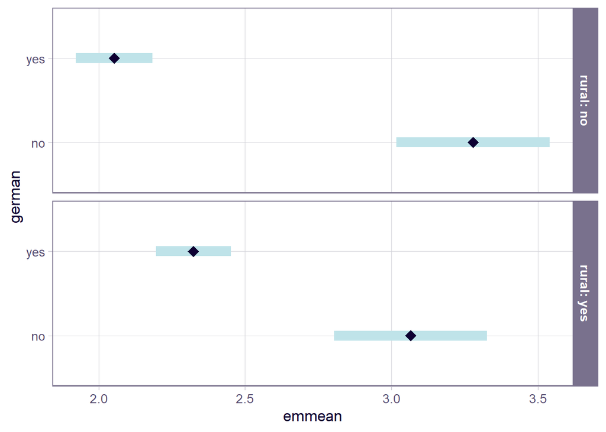

```r
emmeans:::plot.emmGrid(emm_int)
```

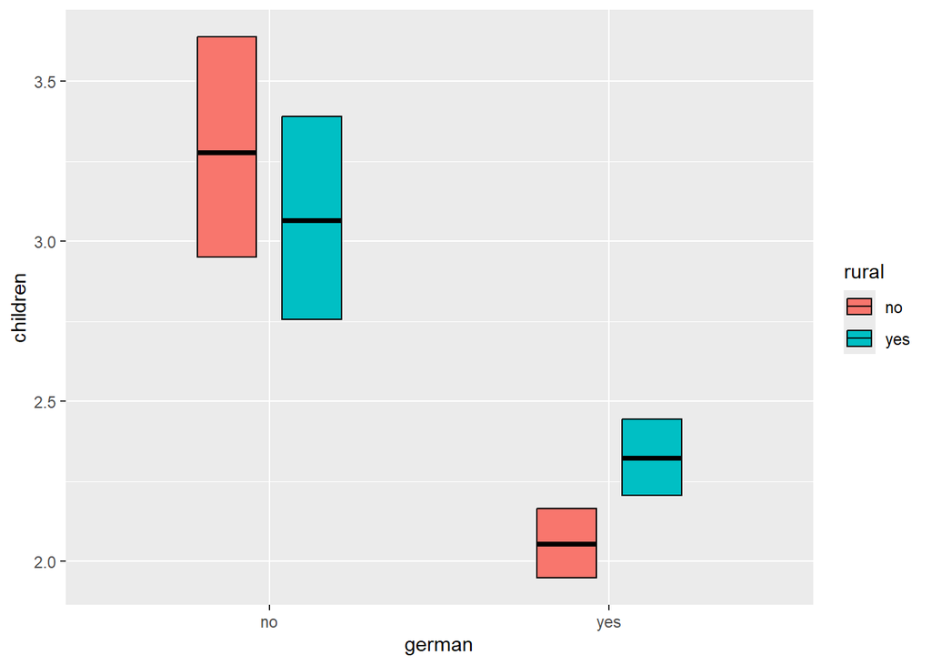

```r
library(ggplot2)
library(Hmisc)
ggplot(data = df,
       mapping = aes(x = german,
                     y = children)) +

  # geom_boxplot() +

  stat_summary(fun.data = mean_cl_boot,
               geom ='crossbar',
               width = 0.5,
               aes(fill = rural),
               position = position_dodge2(padding = 0.3))
```

```r
library(agricolae)

HSD.test(fit7,
         trt = c("german", "rural"),
         console = T)
```

```
Study: fit7 ~ c("german", "rural")

HSD Test for children

Mean Square Error:  2.165923

german:rural,  means

        children      std   r         se Min Max Q25 Q50 Q75
no:no   3.278689 1.984495 122 0.13324213   0  10   2   3   4
no:yes  3.065041 1.768299 123 0.13269939   0   8   2   3   4
yes:no  2.052953 1.281440 491 0.06641722   0   9   1   2   2
yes:yes 2.323471 1.420454 507 0.06536082   0  11   1   2   3

Alpha: 0.05 ; DF Error: 1239
Critical Value of Studentized Range: 3.638094

Groups according to probability of means differences and alpha level( 0.05 )

Treatments with the same letter are not significantly different.

        children groups
no:no   3.278689      a
no:yes  3.065041      a
yes:yes 2.323471      b
yes:no  2.052953      c
```

```r
aggregate(children ~ german + rural,
          data = dr,
          FUN = mean)
```

```
  german rural children
1     no    no 3.278689
2    yes    no 2.052953
3     no   yes 3.065041
4    yes   yes 2.323471
```

## 6.6 Y numeric | Full model

```r
fit8 <- lm(children ~ .,
           data = dr)

summary(fit8)
```

```
Call:
lm(formula = children ~ ., data = dr)

Residuals:
    Min      1Q  Median      3Q     Max
-4.7262 -0.9045 -0.1292  0.6527  8.7602

Coefficients:
                    Estimate Std. Error t value Pr(>|t|)
(Intercept)         3.110423   0.633978   4.906 1.05e-06 ***
germanyes          -0.501622   0.159387  -3.147 0.001688 **
years_school        0.081169   0.067491   1.203 0.229334
voc_trainyes       -0.338967   0.092130  -3.679 0.000244 ***
universityyes      -0.359933   0.326968  -1.101 0.271190
religionMuslim      0.509327   0.148589   3.428 0.000629 ***
religionProtestant  0.267415   0.157365   1.699 0.089510 .
religionOther       1.792991   0.213285   8.407  < 2e-16 ***
year_birth          0.005880   0.005035   1.168 0.243064
ruralyes            0.145994   0.082874   1.762 0.078378 .
age_marriage       -0.074159   0.014092  -5.262 1.68e-07 ***
---
Signif. codes:  0 '***' 0.001 '**' 0.01 '*' 0.05 '.' 0.1 ' ' 1

Residual standard error: 1.406 on 1232 degrees of freedom
Multiple R-squared:  0.1584,    Adjusted R-squared:  0.1515
F-statistic: 23.18 on 10 and 1232 DF,  p-value: < 2.2e-16
```

### 6.6.1 Compare model

```r
fit8a <- lm(children ~ . + age_marriage:german,
           data = dr)

summary(fit8a)
```

```
Call:
lm(formula = children ~ . + age_marriage:german, data = dr)

Residuals:
    Min      1Q  Median      3Q     Max
-4.7746 -0.8986 -0.1310  0.6451  8.7549

Coefficients:
                        Estimate Std. Error t value Pr(>|t|)
(Intercept)             3.427090   0.845710   4.052 5.39e-05 ***
germanyes              -0.902065   0.725298  -1.244 0.213841
years_school            0.079927   0.067545   1.183 0.236913
voc_trainyes           -0.339428   0.092159  -3.683 0.000240 ***
universityyes          -0.364221   0.327146  -1.113 0.265784
religionMuslim          0.511390   0.148675   3.440 0.000602 ***
religionProtestant      0.269818   0.157466   1.714 0.086872 .
religionOther           1.770155   0.217126   8.153 8.69e-16 ***
year_birth              0.005658   0.005051   1.120 0.262862
ruralyes                0.140948   0.083375   1.691 0.091177 .
age_marriage           -0.087076   0.026826  -3.246 0.001202 **
germanyes:age_marriage  0.017547   0.031004   0.566 0.571531
---
Signif. codes:  0 '***' 0.001 '**' 0.01 '*' 0.05 '.' 0.1 ' ' 1

Residual standard error: 1.406 on 1231 degrees of freedom
Multiple R-squared:  0.1586,    Adjusted R-squared:  0.1511
F-statistic: 21.09 on 11 and 1231 DF,  p-value: < 2.2e-16
```

```r
anova(fit1, fit8, test = "F")
```

```
Analysis of Variance Table

Model 1: children ~ years_school + age_marriage
Model 2: children ~ german + years_school + voc_train + university + religion +
    year_birth + rural + age_marriage
  Res.Df    RSS Df Sum of Sq      F    Pr(>F)
1   1240 2746.3
2   1232 2435.7  8     310.6 19.638 < 2.2e-16 ***
---
Signif. codes:  0 '***' 0.001 '**' 0.01 '*' 0.05 '.' 0.1 ' ' 1
```

```r
anova(fit8, fit8a, test = "F")
```

```
Analysis of Variance Table

Model 1: children ~ german + years_school + voc_train + university + religion +
    year_birth + rural + age_marriage
Model 2: children ~ german + years_school + voc_train + university + religion +
    year_birth + rural + age_marriage + age_marriage:german
  Res.Df    RSS Df Sum of Sq      F Pr(>F)
1   1232 2435.7
2   1231 2435.0  1   0.63358 0.3203 0.5715
```

#### 6.6.1.1 Package `stargazer`

https://cran.r-project.org/web/packages/stargazer/vignettes/stargazer.pdf

```r
library(stargazer)

stargazer:::stargazer(fit1, fit6, fit8, fit8a,
                      no.space = T,
                      type = "text")
```

```
============================================================================================================================
                                                                Dependent variable:
                       -----------------------------------------------------------------------------------------------------
                                                                     children
                                 (1)                      (2)                       (3)                       (4)
----------------------------------------------------------------------------------------------------------------------------
years_school                  -0.210***                                            0.081                     0.080
                               (0.045)                                            (0.067)                   (0.068)
voc_trainyes                                                                     -0.339***                 -0.339***
                                                                                  (0.092)                   (0.092)
universityyes                                                                     -0.360                    -0.364
                                                                                  (0.327)                   (0.327)
religionMuslim                                                                   0.509***                  0.511***
                                                                                  (0.149)                   (0.149)
religionProtestant                                                                0.267*                    0.270*
                                                                                  (0.157)                   (0.157)
religionOther                                                                    1.793***                  1.770***
                                                                                  (0.213)                   (0.217)
year_birth                                                                         0.006                     0.006
                                                                                  (0.005)                   (0.005)
age_marriage                  -0.080***                                          -0.074***                 -0.087***
                               (0.014)                                            (0.014)                   (0.027)
germanyes:age_marriage                                                                                       0.018
                                                                                                            (0.031)
ruralyes                                                 -0.214                   0.146*                    0.141*
                                                        (0.188)                   (0.083)                   (0.083)
germanyes                                              -1.226***                 -0.502***                  -0.902
                                                        (0.149)                   (0.159)                   (0.725)
ruralyes:germanyes                                      0.484**
                                                        (0.210)
Constant                       6.148***                 3.279***                 3.110***                  3.427***
                               (0.475)                  (0.133)                   (0.634)                   (0.846)
----------------------------------------------------------------------------------------------------------------------------
Observations                    1,243                    1,243                     1,243                     1,243
R2                              0.051                    0.073                     0.158                     0.159
Adjusted R2                     0.050                    0.070                     0.152                     0.151
Residual Std. Error       1.488 (df = 1240)        1.472 (df = 1239)         1.406 (df = 1232)         1.406 (df = 1231)
F Statistic            33.343*** (df = 2; 1240) 32.376*** (df = 3; 1239) 23.181*** (df = 10; 1232) 21.091*** (df = 11; 1231)
============================================================================================================================
Note:                                                                                            *p<0.1; **p<0.05; ***p<0.01
```

```r
library(stargazer)

stargazer:::stargazer(fit1, fit6, fit8, fit8a,
                      no.space = T,
                      type = "text",
                      title = "So sánh model",
                      # ko hiển thị biến X
                      # keep = names(dr)[-c(4)],
                      # tên model
                      column.labels = c("Model 1",
                            "Model 2",
                            "Model 3",
                            "Model 4"
                            ),
                      add.lines = list(
                        c("AIC",
                          round(AIC(fit1),2),
                          round(AIC(fit6),2),
                          round(AIC(fit8),2),
                          round(AIC(fit8a),2)),
                        c("BIC",
                          round(BIC(fit1),2),
                          round(BIC(fit6),2),
                          round(BIC(fit8),2),
                          round(BIC(fit8a),2))

                        ),
                      # nếu cần exp hệ số
                      # apply.coef = exp,
                      # apply.ci = exp,
                      # keep.stat = c("n"),
                      model.names = T,
                      digits = 3)
```

```
So sánh model
============================================================================================================================
                                                                Dependent variable:
                       -----------------------------------------------------------------------------------------------------
                                                                     children
                                                                        OLS
                               Model 1                  Model 2                   Model 3                   Model 4
                                 (1)                      (2)                       (3)                       (4)
----------------------------------------------------------------------------------------------------------------------------
years_school                  -0.210***                                            0.081                     0.080
                               (0.045)                                            (0.067)                   (0.068)
voc_trainyes                                                                     -0.339***                 -0.339***
                                                                                  (0.092)                   (0.092)
universityyes                                                                     -0.360                    -0.364
                                                                                  (0.327)                   (0.327)
religionMuslim                                                                   0.509***                  0.511***
                                                                                  (0.149)                   (0.149)
religionProtestant                                                                0.267*                    0.270*
                                                                                  (0.157)                   (0.157)
religionOther                                                                    1.793***                  1.770***
                                                                                  (0.213)                   (0.217)
year_birth                                                                         0.006                     0.006
                                                                                  (0.005)                   (0.005)
age_marriage                  -0.080***                                          -0.074***                 -0.087***
                               (0.014)                                            (0.014)                   (0.027)
germanyes:age_marriage                                                                                       0.018
                                                                                                            (0.031)
ruralyes                                                 -0.214                   0.146*                    0.141*
                                                        (0.188)                   (0.083)                   (0.083)
germanyes                                              -1.226***                 -0.502***                  -0.902
                                                        (0.149)                   (0.159)                   (0.725)
ruralyes:germanyes                                      0.484**
                                                        (0.210)
Constant                       6.148***                 3.279***                 3.110***                  3.427***
                               (0.475)                  (0.133)                   (0.634)                   (0.846)
----------------------------------------------------------------------------------------------------------------------------
AIC                            4520.82                  4494.12                   4387.64                   4389.31
BIC                            4541.32                  4519.75                   4449.14                   4455.94
Observations                    1,243                    1,243                     1,243                     1,243
R2                              0.051                    0.073                     0.158                     0.159
Adjusted R2                     0.050                    0.070                     0.152                     0.151
Residual Std. Error       1.488 (df = 1240)        1.472 (df = 1239)         1.406 (df = 1232)         1.406 (df = 1231)
F Statistic            33.343*** (df = 2; 1240) 32.376*** (df = 3; 1239) 23.181*** (df = 10; 1232) 21.091*** (df = 11; 1231)
============================================================================================================================
Note:                                                                                            *p<0.1; **p<0.05; ***p<0.01
```